# Risk Factor Analysis

## Outcome Variable

**Outcome Variable:** wast_rec90d

## Predictor Variables

**Intervention Variable:** meducyrs

**Adjustment Set:**

- arm
- W_mage
- feducyrs
- hhwealth_quart
- W_mhtcm
- W_mwtkg
- W_mbmi
- W_gagebrth
- W_birthwt
- W_birthlen
- single
- W_nrooms
- impsan
- delta_W_mage
- delta_feducyrs
- delta_hhwealth_quart
- delta_W_mhtcm
- delta_W_mwtkg
- delta_W_mbmi
- delta_W_gagebrth
- delta_W_birthwt
- delta_W_birthlen
- delta_single
- delta_W_nrooms
- delta_impsan

## Stratifying Variables

The analysis was stratified on these variable(s):

- agecat
- studyid
- country

## Data Summary

| agecat | studyid | country | meducyrs | wast_rec90d | n_cell | n |
| --- | --- | --- | --- | --- | --- | --- |
| 0-24 months | ki0047075b-MAL-ED | BANGLADESH | High | 0 | 7 | 87 |
| 0-24 months | ki0047075b-MAL-ED | BANGLADESH | High | 1 | 20 | 87 |
| 0-24 months | ki0047075b-MAL-ED | BANGLADESH | Low | 0 | 10 | 87 |
| 0-24 months | ki0047075b-MAL-ED | BANGLADESH | Low | 1 | 23 | 87 |
| 0-24 months | ki0047075b-MAL-ED | BANGLADESH | Medium | 0 | 6 | 87 |
| 0-24 months | ki0047075b-MAL-ED | BANGLADESH | Medium | 1 | 21 | 87 |
| 0-24 months | ki0047075b-MAL-ED | BRAZIL | High | 0 | 0 | 24 |
| 0-24 months | ki0047075b-MAL-ED | BRAZIL | High | 1 | 3 | 24 |
| 0-24 months | ki0047075b-MAL-ED | BRAZIL | Low | 0 | 4 | 24 |
| 0-24 months | ki0047075b-MAL-ED | BRAZIL | Low | 1 | 6 | 24 |
| 0-24 months | ki0047075b-MAL-ED | BRAZIL | Medium | 0 | 2 | 24 |
| 0-24 months | ki0047075b-MAL-ED | BRAZIL | Medium | 1 | 9 | 24 |
| 0-24 months | ki0047075b-MAL-ED | INDIA | High | 0 | 13 | 154 |
| 0-24 months | ki0047075b-MAL-ED | INDIA | High | 1 | 20 | 154 |
| 0-24 months | ki0047075b-MAL-ED | INDIA | Low | 0 | 20 | 154 |
| 0-24 months | ki0047075b-MAL-ED | INDIA | Low | 1 | 42 | 154 |
| 0-24 months | ki0047075b-MAL-ED | INDIA | Medium | 0 | 25 | 154 |
| 0-24 months | ki0047075b-MAL-ED | INDIA | Medium | 1 | 34 | 154 |
| 0-24 months | ki0047075b-MAL-ED | NEPAL | High | 0 | 2 | 93 |
| 0-24 months | ki0047075b-MAL-ED | NEPAL | High | 1 | 15 | 93 |
| 0-24 months | ki0047075b-MAL-ED | NEPAL | Low | 0 | 5 | 93 |
| 0-24 months | ki0047075b-MAL-ED | NEPAL | Low | 1 | 31 | 93 |
| 0-24 months | ki0047075b-MAL-ED | NEPAL | Medium | 0 | 10 | 93 |
| 0-24 months | ki0047075b-MAL-ED | NEPAL | Medium | 1 | 30 | 93 |
| 0-24 months | ki0047075b-MAL-ED | PERU | High | 0 | 0 | 35 |
| 0-24 months | ki0047075b-MAL-ED | PERU | High | 1 | 3 | 35 |
| 0-24 months | ki0047075b-MAL-ED | PERU | Low | 0 | 2 | 35 |
| 0-24 months | ki0047075b-MAL-ED | PERU | Low | 1 | 15 | 35 |
| 0-24 months | ki0047075b-MAL-ED | PERU | Medium | 0 | 4 | 35 |
| 0-24 months | ki0047075b-MAL-ED | PERU | Medium | 1 | 11 | 35 |

[output cut: 438 more lines]

The following strata were considered:

- agecat: 0-24 months, studyid: ki0047075b-MAL-ED, country: BANGLADESH
- agecat: 0-24 months, studyid: ki0047075b-MAL-ED, country: BRAZIL
- agecat: 0-24 months, studyid: ki0047075b-MAL-ED, country: INDIA
- agecat: 0-24 months, studyid: ki0047075b-MAL-ED, country: NEPAL
- agecat: 0-24 months, studyid: ki0047075b-MAL-ED, country: PERU
- agecat: 0-24 months, studyid: ki0047075b-MAL-ED, country: SOUTH AFRICA
- agecat: 0-24 months, studyid: ki0047075b-MAL-ED, country: TANZANIA, UNITED REPUBLIC OF
- agecat: 0-24 months, studyid: ki1000108-CMC-V-BCS-2002, country: INDIA
- agecat: 0-24 months, studyid: ki1000108-IRC, country: INDIA
- agecat: 0-24 months, studyid: ki1000109-EE, country: PAKISTAN
- agecat: 0-24 months, studyid: ki1000304b-SAS-CompFeed, country: INDIA
- agecat: 0-24 months, studyid: ki1000304b-SAS-FoodSuppl, country: INDIA
- agecat: 0-24 months, studyid: ki1017093-NIH-Birth, country: BANGLADESH
- agecat: 0-24 months, studyid: ki1017093b-PROVIDE, country: BANGLADESH
- agecat: 0-24 months, studyid: ki1017093c-NIH-Crypto, country: BANGLADESH
- agecat: 0-24 months, studyid: ki1066203-TanzaniaChild2, country: TANZANIA, UNITED REPUBLIC OF
- agecat: 0-24 months, studyid: ki1112895-Guatemala BSC, country: GUATEMALA
- agecat: 0-24 months, studyid: ki1113344-GMS-Nepal, country: NEPAL
- agecat: 0-24 months, studyid: ki1119695-PROBIT, country: BELARUS
- agecat: 0-24 months, studyid: ki1126311-ZVITAMBO, country: ZIMBABWE
- agecat: 0-24 months, studyid: ki1135781-COHORTS, country: GUATEMALA
- agecat: 0-24 months, studyid: ki1135781-COHORTS, country: INDIA
- agecat: 0-24 months, studyid: ki1135781-COHORTS, country: PHILIPPINES
- agecat: 0-24 months, studyid: ki1148112-LCNI-5, country: MALAWI
- agecat: 0-24 months, studyid: kiGH5241-JiVitA-3, country: BANGLADESH
- agecat: 0-24 months, studyid: kiGH5241-JiVitA-4, country: BANGLADESH
- agecat: 0-6 months, studyid: ki0047075b-MAL-ED, country: BANGLADESH
- agecat: 0-6 months, studyid: ki0047075b-MAL-ED, country: BRAZIL
- agecat: 0-6 months, studyid: ki0047075b-MAL-ED, country: INDIA
- agecat: 0-6 months, studyid: ki0047075b-MAL-ED, country: NEPAL
- agecat: 0-6 months, studyid: ki0047075b-MAL-ED, country: PERU
- agecat: 0-6 months, studyid: ki0047075b-MAL-ED, country: SOUTH AFRICA
- agecat: 0-6 months, studyid: ki0047075b-MAL-ED, country: TANZANIA, UNITED REPUBLIC OF
- agecat: 0-6 months, studyid: ki1000108-CMC-V-BCS-2002, country: INDIA
- agecat: 0-6 months, studyid: ki1000108-IRC, country: INDIA
- agecat: 0-6 months, studyid: ki1000109-EE, country: PAKISTAN
- agecat: 0-6 months, studyid: ki1000304b-SAS-CompFeed, country: INDIA
- agecat: 0-6 months, studyid: ki1000304b-SAS-FoodSuppl, country: INDIA
- agecat: 0-6 months, studyid: ki1017093-NIH-Birth, country: BANGLADESH
- agecat: 0-6 months, studyid: ki1017093b-PROVIDE, country: BANGLADESH
- agecat: 0-6 months, studyid: ki1017093c-NIH-Crypto, country: BANGLADESH
- agecat: 0-6 months, studyid: ki1066203-TanzaniaChild2, country: TANZANIA, UNITED REPUBLIC OF
- agecat: 0-6 months, studyid: ki1112895-Guatemala BSC, country: GUATEMALA
- agecat: 0-6 months, studyid: ki1113344-GMS-Nepal, country: NEPAL
- agecat: 0-6 months, studyid: ki1119695-PROBIT, country: BELARUS
- agecat: 0-6 months, studyid: ki1126311-ZVITAMBO, country: ZIMBABWE
- agecat: 0-6 months, studyid: ki1135781-COHORTS, country: GUATEMALA
- agecat: 0-6 months, studyid: ki1135781-COHORTS, country: INDIA
- agecat: 0-6 months, studyid: ki1135781-COHORTS, country: PHILIPPINES
- agecat: 0-6 months, studyid: ki1148112-LCNI-5, country: MALAWI
- agecat: 0-6 months, studyid: kiGH5241-JiVitA-3, country: BANGLADESH
- agecat: 0-6 months, studyid: kiGH5241-JiVitA-4, country: BANGLADESH
- agecat: 6-24 months, studyid: ki0047075b-MAL-ED, country: BANGLADESH
- agecat: 6-24 months, studyid: ki0047075b-MAL-ED, country: BRAZIL
- agecat: 6-24 months, studyid: ki0047075b-MAL-ED, country: INDIA
- agecat: 6-24 months, studyid: ki0047075b-MAL-ED, country: NEPAL
- agecat: 6-24 months, studyid: ki0047075b-MAL-ED, country: PERU
- agecat: 6-24 months, studyid: ki0047075b-MAL-ED, country: SOUTH AFRICA
- agecat: 6-24 months, studyid: ki0047075b-MAL-ED, country: TANZANIA, UNITED REPUBLIC OF
- agecat: 6-24 months, studyid: ki1000108-CMC-V-BCS-2002, country: INDIA
- agecat: 6-24 months, studyid: ki1000108-IRC, country: INDIA
- agecat: 6-24 months, studyid: ki1000109-EE, country: PAKISTAN
- agecat: 6-24 months, studyid: ki1000304b-SAS-CompFeed, country: INDIA
- agecat: 6-24 months, studyid: ki1000304b-SAS-FoodSuppl, country: INDIA
- agecat: 6-24 months, studyid: ki1017093-NIH-Birth, country: BANGLADESH
- agecat: 6-24 months, studyid: ki1017093b-PROVIDE, country: BANGLADESH
- agecat: 6-24 months, studyid: ki1017093c-NIH-Crypto, country: BANGLADESH
- agecat: 6-24 months, studyid: ki1066203-TanzaniaChild2, country: TANZANIA, UNITED REPUBLIC OF
- agecat: 6-24 months, studyid: ki1112895-Guatemala BSC, country: GUATEMALA
- agecat: 6-24 months, studyid: ki1113344-GMS-Nepal, country: NEPAL
- agecat: 6-24 months, studyid: ki1119695-PROBIT, country: BELARUS
- agecat: 6-24 months, studyid: ki1126311-ZVITAMBO, country: ZIMBABWE
- agecat: 6-24 months, studyid: ki1135781-COHORTS, country: GUATEMALA
- agecat: 6-24 months, studyid: ki1135781-COHORTS, country: INDIA
- agecat: 6-24 months, studyid: ki1135781-COHORTS, country: PHILIPPINES
- agecat: 6-24 months, studyid: ki1148112-LCNI-5, country: MALAWI
- agecat: 6-24 months, studyid: kiGH5241-JiVitA-3, country: BANGLADESH
- agecat: 6-24 months, studyid: kiGH5241-JiVitA-4, country: BANGLADESH

### Dropped Strata

Some strata were dropped due to rare outcomes:

- agecat: 0-24 months, studyid: ki0047075b-MAL-ED, country: BRAZIL
- agecat: 0-24 months, studyid: ki0047075b-MAL-ED, country: NEPAL
- agecat: 0-24 months, studyid: ki0047075b-MAL-ED, country: PERU
- agecat: 0-24 months, studyid: ki0047075b-MAL-ED, country: SOUTH AFRICA
- agecat: 0-24 months, studyid: ki0047075b-MAL-ED, country: TANZANIA, UNITED REPUBLIC OF
- agecat: 0-24 months, studyid: ki1000109-EE, country: PAKISTAN
- agecat: 0-24 months, studyid: ki1000304b-SAS-FoodSuppl, country: INDIA
- agecat: 0-24 months, studyid: ki1112895-Guatemala BSC, country: GUATEMALA
- agecat: 0-24 months, studyid: ki1148112-LCNI-5, country: MALAWI
- agecat: 0-6 months, studyid: ki0047075b-MAL-ED, country: BANGLADESH
- agecat: 0-6 months, studyid: ki0047075b-MAL-ED, country: BRAZIL
- agecat: 0-6 months, studyid: ki0047075b-MAL-ED, country: NEPAL
- agecat: 0-6 months, studyid: ki0047075b-MAL-ED, country: PERU
- agecat: 0-6 months, studyid: ki0047075b-MAL-ED, country: SOUTH AFRICA
- agecat: 0-6 months, studyid: ki0047075b-MAL-ED, country: TANZANIA, UNITED REPUBLIC OF
- agecat: 0-6 months, studyid: ki1000109-EE, country: PAKISTAN
- agecat: 0-6 months, studyid: ki1000304b-SAS-FoodSuppl, country: INDIA
- agecat: 0-6 months, studyid: ki1066203-TanzaniaChild2, country: TANZANIA, UNITED REPUBLIC OF
- agecat: 0-6 months, studyid: ki1112895-Guatemala BSC, country: GUATEMALA
- agecat: 0-6 months, studyid: ki1148112-LCNI-5, country: MALAWI
- agecat: 6-24 months, studyid: ki0047075b-MAL-ED, country: BANGLADESH
- agecat: 6-24 months, studyid: ki0047075b-MAL-ED, country: BRAZIL
- agecat: 6-24 months, studyid: ki0047075b-MAL-ED, country: NEPAL
- agecat: 6-24 months, studyid: ki0047075b-MAL-ED, country: PERU
- agecat: 6-24 months, studyid: ki0047075b-MAL-ED, country: SOUTH AFRICA
- agecat: 6-24 months, studyid: ki0047075b-MAL-ED, country: TANZANIA, UNITED REPUBLIC OF
- agecat: 6-24 months, studyid: ki1000109-EE, country: PAKISTAN
- agecat: 6-24 months, studyid: ki1000304b-SAS-FoodSuppl, country: INDIA
- agecat: 6-24 months, studyid: ki1017093c-NIH-Crypto, country: BANGLADESH
- agecat: 6-24 months, studyid: ki1112895-Guatemala BSC, country: GUATEMALA
- agecat: 6-24 months, studyid: ki1135781-COHORTS, country: GUATEMALA
- agecat: 6-24 months, studyid: ki1135781-COHORTS, country: INDIA
- agecat: 6-24 months, studyid: ki1148112-LCNI-5, country: MALAWI
- agecat: 6-24 months, studyid: kiGH5241-JiVitA-3, country: BANGLADESH

## Methods Detail

We’re interested in the causal parameters $E[Y_a]$ for all values of $a \in \mathcal{A}$. These parameters represent the mean outcome if, possibly contrary to fact, we intervened to set all units to have $A=a$. Under the randomization and positivity assumptions, these are identified by the statistical parameters $\psi_a=E_W[E_{Y|A,W}(Y|A=a,W)]$. In addition, we’re interested in the mean of $Y$, $E[Y]$ under no intervention (the observed mean). We will estimate these parameters by using SuperLearner to fit the relevant likelihood factors – $E_{Y|A,W}(Y|A=a,W)$ and $p(A=a|W)$, and then updating our likelihood fit using a joint TMLE.

For unadjusted analyses ($W=\{\}$), initial likelihoods were estimated using Lrnr_glm to estimate the simple $E(Y|A)$ and Lrnr_mean to estimate $p(A)$. For adjusted analyses, a small library containing Lrnr_glmnet, Lrnr_xgboost, and Lrnr_mean was used.

Having estimated these parameters, we will then use the delta method to estimate relative risks and attributable risks relative to a prespecified baseline level of $A$.

# Results Detail

## Results Plots

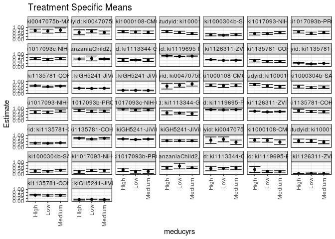

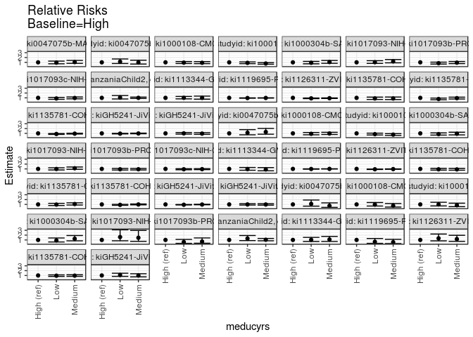

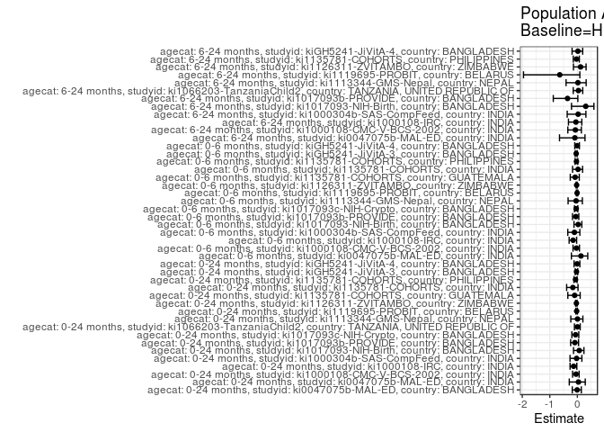

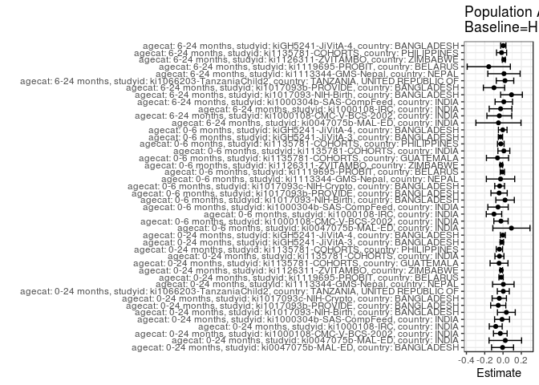

## Results Table

### Parameter: TSM

| agecat | studyid | country | intervention_level | baseline_level | estimate | ci_lower | ci_upper |
| --- | --- | --- | --- | --- | --- | --- | --- |
| 0-24 months | ki0047075b-MAL-ED | BANGLADESH | High | NA | 0.7407407 | 0.6159882 | 0.8654933 |
| 0-24 months | ki0047075b-MAL-ED | BANGLADESH | Low | NA | 0.6969697 | 0.5338973 | 0.8600421 |
| 0-24 months | ki0047075b-MAL-ED | BANGLADESH | Medium | NA | 0.7777778 | 0.5967442 | 0.9588114 |
| 0-24 months | ki0047075b-MAL-ED | INDIA | High | NA | 0.5984365 | 0.3907820 | 0.8060910 |
| 0-24 months | ki0047075b-MAL-ED | INDIA | Low | NA | 0.6814092 | 0.5461753 | 0.8166431 |
| 0-24 months | ki0047075b-MAL-ED | INDIA | Medium | NA | 0.5801373 | 0.4549495 | 0.7053250 |
| 0-24 months | ki1000108-CMC-V-BCS-2002 | INDIA | High | NA | 0.6595005 | 0.5642757 | 0.7547254 |
| 0-24 months | ki1000108-CMC-V-BCS-2002 | INDIA | Low | NA | 0.6206728 | 0.5257799 | 0.7155657 |
| 0-24 months | ki1000108-CMC-V-BCS-2002 | INDIA | Medium | NA | 0.6027498 | 0.4990262 | 0.7064733 |
| 0-24 months | ki1000108-IRC | INDIA | High | NA | 0.6698836 | 0.5902434 | 0.7495238 |
| 0-24 months | ki1000108-IRC | INDIA | Low | NA | 0.5984454 | 0.5028659 | 0.6940249 |
| 0-24 months | ki1000108-IRC | INDIA | Medium | NA | 0.5097824 | 0.4175343 | 0.6020306 |
| 0-24 months | ki1000304b-SAS-CompFeed | INDIA | High | NA | 0.3915023 | 0.3016167 | 0.4813879 |
| 0-24 months | ki1000304b-SAS-CompFeed | INDIA | Low | NA | 0.3572655 | 0.3085198 | 0.4060113 |
| 0-24 months | ki1000304b-SAS-CompFeed | INDIA | Medium | NA | 0.4134430 | 0.3496240 | 0.4772620 |
| 0-24 months | ki1017093-NIH-Birth | BANGLADESH | High | NA | 0.4839952 | 0.3717518 | 0.5962386 |
| 0-24 months | ki1017093-NIH-Birth | BANGLADESH | Low | NA | 0.4948844 | 0.4234262 | 0.5663426 |
| 0-24 months | ki1017093-NIH-Birth | BANGLADESH | Medium | NA | 0.5772806 | 0.4842428 | 0.6703183 |
| 0-24 months | ki1017093b-PROVIDE | BANGLADESH | High | NA | 0.6334603 | 0.5382078 | 0.7287128 |
| 0-24 months | ki1017093b-PROVIDE | BANGLADESH | Low | NA | 0.5201328 | 0.4249895 | 0.6152762 |
| 0-24 months | ki1017093b-PROVIDE | BANGLADESH | Medium | NA | 0.5934846 | 0.4926206 | 0.6943486 |
| 0-24 months | ki1017093c-NIH-Crypto | BANGLADESH | High | NA | 0.6636752 | 0.5662460 | 0.7611043 |
| 0-24 months | ki1017093c-NIH-Crypto | BANGLADESH | Low | NA | 0.5837030 | 0.4854337 | 0.6819723 |
| 0-24 months | ki1017093c-NIH-Crypto | BANGLADESH | Medium | NA | 0.6459196 | 0.5627702 | 0.7290690 |
| 0-24 months | ki1066203-TanzaniaChild2 | TANZANIA, UNITED REPUBLIC OF | High | NA | 0.6235955 | 0.5481204 | 0.6990706 |
| 0-24 months | ki1066203-TanzaniaChild2 | TANZANIA, UNITED REPUBLIC OF | Low | NA | 0.6666667 | 0.4628279 | 0.8705055 |
| 0-24 months | ki1066203-TanzaniaChild2 | TANZANIA, UNITED REPUBLIC OF | Medium | NA | 0.6254902 | 0.5809696 | 0.6700108 |
| 0-24 months | ki1113344-GMS-Nepal | NEPAL | High | NA | 0.5359417 | 0.4120283 | 0.6598551 |
| 0-24 months | ki1113344-GMS-Nepal | NEPAL | Low | NA | 0.5404012 | 0.4914500 | 0.5893524 |
| 0-24 months | ki1113344-GMS-Nepal | NEPAL | Medium | NA | 0.5324269 | 0.4169737 | 0.6478800 |

[output cut: 102 more lines]

### Parameter: E(Y)

| agecat | studyid | country | intervention_level | baseline_level | estimate | ci_lower | ci_upper |
| --- | --- | --- | --- | --- | --- | --- | --- |
| 0-24 months | ki0047075b-MAL-ED | BANGLADESH | NA | NA | 0.7356322 | 0.6433278 | 0.8279366 |
| 0-24 months | ki0047075b-MAL-ED | INDIA | NA | NA | 0.6233766 | 0.5382453 | 0.7085080 |
| 0-24 months | ki1000108-CMC-V-BCS-2002 | INDIA | NA | NA | 0.6296296 | 0.5734927 | 0.6857666 |
| 0-24 months | ki1000108-IRC | INDIA | NA | NA | 0.5898734 | 0.5376978 | 0.6420491 |
| 0-24 months | ki1000304b-SAS-CompFeed | INDIA | NA | NA | 0.3808354 | 0.3457640 | 0.4159068 |
| 0-24 months | ki1017093-NIH-Birth | BANGLADESH | NA | NA | 0.5201900 | 0.4695846 | 0.5707955 |
| 0-24 months | ki1017093b-PROVIDE | BANGLADESH | NA | NA | 0.5811688 | 0.5245443 | 0.6377934 |
| 0-24 months | ki1017093c-NIH-Crypto | BANGLADESH | NA | NA | 0.6225806 | 0.5684562 | 0.6767051 |
| 0-24 months | ki1066203-TanzaniaChild2 | TANZANIA, UNITED REPUBLIC OF | NA | NA | 0.6264045 | 0.5887191 | 0.6640899 |
| 0-24 months | ki1113344-GMS-Nepal | NEPAL | NA | NA | 0.5390625 | 0.4966112 | 0.5815138 |
| 0-24 months | ki1119695-PROBIT | BELARUS | NA | NA | 0.8612051 | 0.8511051 | 0.8713052 |
| 0-24 months | ki1126311-ZVITAMBO | ZIMBABWE | NA | NA | 0.5430867 | 0.5266769 | 0.5594965 |
| 0-24 months | ki1135781-COHORTS | GUATEMALA | NA | NA | 0.4403183 | 0.3884516 | 0.4921850 |
| 0-24 months | ki1135781-COHORTS | INDIA | NA | NA | 0.2397357 | 0.2214428 | 0.2580286 |
| 0-24 months | ki1135781-COHORTS | PHILIPPINES | NA | NA | 0.6068680 | 0.5823645 | 0.6313715 |
| 0-24 months | kiGH5241-JiVitA-3 | BANGLADESH | NA | NA | 0.4224309 | 0.4113024 | 0.4335594 |
| 0-24 months | kiGH5241-JiVitA-4 | BANGLADESH | NA | NA | 0.2580019 | 0.2386523 | 0.2773515 |
| 0-6 months | ki0047075b-MAL-ED | INDIA | NA | NA | 0.7027027 | 0.5947731 | 0.8106323 |
| 0-6 months | ki1000108-CMC-V-BCS-2002 | INDIA | NA | NA | 0.6716418 | 0.6057305 | 0.7375531 |
| 0-6 months | ki1000108-IRC | INDIA | NA | NA | 0.6375000 | 0.5751450 | 0.6998550 |
| 0-6 months | ki1000304b-SAS-CompFeed | INDIA | NA | NA | 0.5131965 | 0.4596632 | 0.5667297 |
| 0-6 months | ki1017093-NIH-Birth | BANGLADESH | NA | NA | 0.7130045 | 0.6535890 | 0.7724200 |
| 0-6 months | ki1017093b-PROVIDE | BANGLADESH | NA | NA | 0.7837838 | 0.7252863 | 0.8422812 |
| 0-6 months | ki1017093c-NIH-Crypto | BANGLADESH | NA | NA | 0.8934010 | 0.8497799 | 0.9370221 |
| 0-6 months | ki1113344-GMS-Nepal | NEPAL | NA | NA | 0.6030534 | 0.5432663 | 0.6628406 |
| 0-6 months | ki1119695-PROBIT | BELARUS | NA | NA | 0.8855266 | 0.8758983 | 0.8951550 |
| 0-6 months | ki1126311-ZVITAMBO | ZIMBABWE | NA | NA | 0.7474145 | 0.7304420 | 0.7643869 |
| 0-6 months | ki1135781-COHORTS | GUATEMALA | NA | NA | 0.7452830 | 0.6866274 | 0.8039386 |
| 0-6 months | ki1135781-COHORTS | INDIA | NA | NA | 0.3595188 | 0.3344897 | 0.3845478 |
| 0-6 months | ki1135781-COHORTS | PHILIPPINES | NA | NA | 0.7367021 | 0.7051294 | 0.7682749 |
| 0-6 months | kiGH5241-JiVitA-3 | BANGLADESH | NA | NA | 0.6754071 | 0.6620619 | 0.6887522 |
| 0-6 months | kiGH5241-JiVitA-4 | BANGLADESH | NA | NA | 0.5583942 | 0.5167799 | 0.6000084 |
| 6-24 months | ki0047075b-MAL-ED | INDIA | NA | NA | 0.5500000 | 0.4255057 | 0.6744943 |
| 6-24 months | ki1000108-CMC-V-BCS-2002 | INDIA | NA | NA | 0.5609756 | 0.4682842 | 0.6536670 |
| 6-24 months | ki1000108-IRC | INDIA | NA | NA | 0.5161290 | 0.4322562 | 0.6000019 |
| 6-24 months | ki1000304b-SAS-CompFeed | INDIA | NA | NA | 0.2854123 | 0.2436284 | 0.3271961 |
| 6-24 months | ki1017093-NIH-Birth | BANGLADESH | NA | NA | 0.3030303 | 0.2377927 | 0.3682679 |
| 6-24 months | ki1017093b-PROVIDE | BANGLADESH | NA | NA | 0.2764228 | 0.1950773 | 0.3577682 |
| 6-24 months | ki1066203-TanzaniaChild2 | TANZANIA, UNITED REPUBLIC OF | NA | NA | 0.5564516 | 0.5041613 | 0.6087419 |
| 6-24 months | ki1113344-GMS-Nepal | NEPAL | NA | NA | 0.4947090 | 0.4399319 | 0.5494861 |
| 6-24 months | ki1119695-PROBIT | BELARUS | NA | NA | 0.2440476 | 0.1791134 | 0.3089818 |
| 6-24 months | ki1126311-ZVITAMBO | ZIMBABWE | NA | NA | 0.0739726 | 0.0585427 | 0.0894025 |
| 6-24 months | ki1135781-COHORTS | PHILIPPINES | NA | NA | 0.5026681 | 0.4688378 | 0.5364984 |
| 6-24 months | kiGH5241-JiVitA-4 | BANGLADESH | NA | NA | 0.1492734 | 0.1316631 | 0.1668838 |

### Parameter: RR

| agecat | studyid | country | intervention_level | baseline_level | estimate | ci_lower | ci_upper |
| --- | --- | --- | --- | --- | --- | --- | --- |
| 0-24 months | ki0047075b-MAL-ED | BANGLADESH | High | High | 1.0000000 | 1.0000000 | 1.0000000 |
| 0-24 months | ki0047075b-MAL-ED | BANGLADESH | Low | High | 0.9409091 | 0.7050517 | 1.2556667 |
| 0-24 months | ki0047075b-MAL-ED | BANGLADESH | Medium | High | 1.0500000 | 0.7881118 | 1.3989132 |
| 0-24 months | ki0047075b-MAL-ED | INDIA | High | High | 1.0000000 | 1.0000000 | 1.0000000 |
| 0-24 months | ki0047075b-MAL-ED | INDIA | Low | High | 1.1386492 | 0.7623673 | 1.7006526 |
| 0-24 months | ki0047075b-MAL-ED | INDIA | Medium | High | 0.9694217 | 0.6502964 | 1.4451540 |
| 0-24 months | ki1000108-CMC-V-BCS-2002 | INDIA | High | High | 1.0000000 | 1.0000000 | 1.0000000 |
| 0-24 months | ki1000108-CMC-V-BCS-2002 | INDIA | Low | High | 0.9411256 | 0.7622565 | 1.1619677 |
| 0-24 months | ki1000108-CMC-V-BCS-2002 | INDIA | Medium | High | 0.9139489 | 0.7299981 | 1.1442531 |
| 0-24 months | ki1000108-IRC | INDIA | High | High | 1.0000000 | 1.0000000 | 1.0000000 |
| 0-24 months | ki1000108-IRC | INDIA | Low | High | 0.8933574 | 0.7321426 | 1.0900709 |
| 0-24 months | ki1000108-IRC | INDIA | Medium | High | 0.7610015 | 0.6133547 | 0.9441899 |
| 0-24 months | ki1000304b-SAS-CompFeed | INDIA | High | High | 1.0000000 | 1.0000000 | 1.0000000 |
| 0-24 months | ki1000304b-SAS-CompFeed | INDIA | Low | High | 0.9125504 | 0.6990943 | 1.1911816 |
| 0-24 months | ki1000304b-SAS-CompFeed | INDIA | Medium | High | 1.0560424 | 0.8011769 | 1.3919842 |
| 0-24 months | ki1017093-NIH-Birth | BANGLADESH | High | High | 1.0000000 | 1.0000000 | 1.0000000 |
| 0-24 months | ki1017093-NIH-Birth | BANGLADESH | Low | High | 1.0224986 | 0.7788012 | 1.3424521 |
| 0-24 months | ki1017093-NIH-Birth | BANGLADESH | Medium | High | 1.1927402 | 0.8994032 | 1.5817481 |
| 0-24 months | ki1017093b-PROVIDE | BANGLADESH | High | High | 1.0000000 | 1.0000000 | 1.0000000 |
| 0-24 months | ki1017093b-PROVIDE | BANGLADESH | Low | High | 0.8210977 | 0.6483272 | 1.0399092 |
| 0-24 months | ki1017093b-PROVIDE | BANGLADESH | Medium | High | 0.9368931 | 0.7464921 | 1.1758579 |
| 0-24 months | ki1017093c-NIH-Crypto | BANGLADESH | High | High | 1.0000000 | 1.0000000 | 1.0000000 |
| 0-24 months | ki1017093c-NIH-Crypto | BANGLADESH | Low | High | 0.8795010 | 0.7046491 | 1.0977408 |
| 0-24 months | ki1017093c-NIH-Crypto | BANGLADESH | Medium | High | 0.9732466 | 0.8019000 | 1.1812058 |
| 0-24 months | ki1066203-TanzaniaChild2 | TANZANIA, UNITED REPUBLIC OF | High | High | 1.0000000 | 1.0000000 | 1.0000000 |
| 0-24 months | ki1066203-TanzaniaChild2 | TANZANIA, UNITED REPUBLIC OF | Low | High | 1.0690691 | 0.7694770 | 1.4853058 |
| 0-24 months | ki1066203-TanzaniaChild2 | TANZANIA, UNITED REPUBLIC OF | Medium | High | 1.0030383 | 0.8716480 | 1.1542341 |
| 0-24 months | ki1113344-GMS-Nepal | NEPAL | High | High | 1.0000000 | 1.0000000 | 1.0000000 |
| 0-24 months | ki1113344-GMS-Nepal | NEPAL | Low | High | 1.0083209 | 0.7870533 | 1.2917943 |
| 0-24 months | ki1113344-GMS-Nepal | NEPAL | Medium | High | 0.9934418 | 0.7241936 | 1.3627939 |

[output cut: 102 more lines]

### Parameter: PAR

| agecat | studyid | country | intervention_level | baseline_level | estimate | ci_lower | ci_upper |
| --- | --- | --- | --- | --- | --- | --- | --- |
| 0-24 months | ki0047075b-MAL-ED | BANGLADESH | High | NA | -0.0051086 | -0.1250382 | 0.1148211 |
| 0-24 months | ki0047075b-MAL-ED | INDIA | High | NA | 0.0249402 | -0.1529010 | 0.2027813 |
| 0-24 months | ki1000108-CMC-V-BCS-2002 | INDIA | High | NA | -0.0298709 | -0.1042863 | 0.0445445 |
| 0-24 months | ki1000108-IRC | INDIA | High | NA | -0.0800101 | -0.1504789 | -0.0095414 |
| 0-24 months | ki1000304b-SAS-CompFeed | INDIA | High | NA | -0.0106669 | -0.0921451 | 0.0708113 |
| 0-24 months | ki1017093-NIH-Birth | BANGLADESH | High | NA | 0.0361948 | -0.0611718 | 0.1335614 |
| 0-24 months | ki1017093b-PROVIDE | BANGLADESH | High | NA | -0.0522915 | -0.1349219 | 0.0303388 |
| 0-24 months | ki1017093c-NIH-Crypto | BANGLADESH | High | NA | -0.0410945 | -0.1192385 | 0.0370494 |
| 0-24 months | ki1066203-TanzaniaChild2 | TANZANIA, UNITED REPUBLIC OF | High | NA | 0.0028090 | -0.0625216 | 0.0681396 |
| 0-24 months | ki1113344-GMS-Nepal | NEPAL | High | NA | 0.0031208 | -0.1142472 | 0.1204889 |
| 0-24 months | ki1119695-PROBIT | BELARUS | High | NA | -0.0213695 | -0.0448006 | 0.0020615 |
| 0-24 months | ki1126311-ZVITAMBO | ZIMBABWE | High | NA | -0.0189973 | -0.0326528 | -0.0053417 |
| 0-24 months | ki1135781-COHORTS | GUATEMALA | High | NA | -0.0436899 | -0.1413933 | 0.0540134 |
| 0-24 months | ki1135781-COHORTS | INDIA | High | NA | -0.0392217 | -0.0885103 | 0.0100669 |
| 0-24 months | ki1135781-COHORTS | PHILIPPINES | High | NA | -0.0396457 | -0.0741768 | -0.0051147 |
| 0-24 months | kiGH5241-JiVitA-3 | BANGLADESH | High | NA | -0.0133096 | -0.0322958 | 0.0056767 |
| 0-24 months | kiGH5241-JiVitA-4 | BANGLADESH | High | NA | -0.0021911 | -0.0292081 | 0.0248259 |
| 0-6 months | ki0047075b-MAL-ED | INDIA | High | NA | 0.0915916 | -0.1113297 | 0.2945128 |
| 0-6 months | ki1000108-CMC-V-BCS-2002 | INDIA | High | NA | -0.0224371 | -0.1003619 | 0.0554876 |
| 0-6 months | ki1000108-IRC | INDIA | High | NA | -0.0988299 | -0.1831756 | -0.0144842 |
| 0-6 months | ki1000304b-SAS-CompFeed | INDIA | High | NA | -0.0547972 | -0.1660511 | 0.0564566 |
| 0-6 months | ki1017093-NIH-Birth | BANGLADESH | High | NA | 0.0222072 | -0.0788076 | 0.1232219 |
| 0-6 months | ki1017093b-PROVIDE | BANGLADESH | High | NA | -0.0431393 | -0.1318940 | 0.0456154 |
| 0-6 months | ki1017093c-NIH-Crypto | BANGLADESH | High | NA | -0.0371545 | -0.0905895 | 0.0162804 |
| 0-6 months | ki1113344-GMS-Nepal | NEPAL | High | NA | -0.0274371 | -0.1821732 | 0.1272991 |
| 0-6 months | ki1119695-PROBIT | BELARUS | High | NA | -0.0075789 | -0.0307216 | 0.0155637 |
| 0-6 months | ki1126311-ZVITAMBO | ZIMBABWE | High | NA | -0.0188083 | -0.0326507 | -0.0049659 |
| 0-6 months | ki1135781-COHORTS | GUATEMALA | High | NA | -0.0602725 | -0.1812521 | 0.0607071 |
| 0-6 months | ki1135781-COHORTS | INDIA | High | NA | 0.0089624 | -0.0560037 | 0.0739284 |
| 0-6 months | ki1135781-COHORTS | PHILIPPINES | High | NA | -0.0244366 | -0.0605019 | 0.0116287 |
| 0-6 months | kiGH5241-JiVitA-3 | BANGLADESH | High | NA | -0.0283619 | -0.0515777 | -0.0051462 |
| 0-6 months | kiGH5241-JiVitA-4 | BANGLADESH | High | NA | -0.0034437 | -0.0504600 | 0.0435726 |
| 6-24 months | ki0047075b-MAL-ED | INDIA | High | NA | -0.0500000 | -0.2964156 | 0.1964156 |
| 6-24 months | ki1000108-CMC-V-BCS-2002 | INDIA | High | NA | -0.0405627 | -0.1763479 | 0.0952225 |
| 6-24 months | ki1000108-IRC | INDIA | High | NA | -0.0269746 | -0.1511239 | 0.0971747 |
| 6-24 months | ki1000304b-SAS-CompFeed | INDIA | High | NA | 0.0083132 | -0.0868119 | 0.1034384 |
| 6-24 months | ki1017093-NIH-Birth | BANGLADESH | High | NA | 0.0925040 | -0.0259710 | 0.2109790 |
| 6-24 months | ki1017093b-PROVIDE | BANGLADESH | High | NA | -0.0985772 | -0.2149020 | 0.0177476 |
| 6-24 months | ki1066203-TanzaniaChild2 | TANZANIA, UNITED REPUBLIC OF | High | NA | 0.0215679 | -0.0739879 | 0.1171237 |
| 6-24 months | ki1113344-GMS-Nepal | NEPAL | High | NA | 0.0102968 | -0.1662089 | 0.1868024 |
| 6-24 months | ki1119695-PROBIT | BELARUS | High | NA | -0.1559524 | -0.3917880 | 0.0798833 |
| 6-24 months | ki1126311-ZVITAMBO | ZIMBABWE | High | NA | 0.0086747 | -0.0082403 | 0.0255897 |
| 6-24 months | ki1135781-COHORTS | PHILIPPINES | High | NA | -0.0159086 | -0.0708528 | 0.0390356 |
| 6-24 months | kiGH5241-JiVitA-4 | BANGLADESH | High | NA | 0.0030611 | -0.0255388 | 0.0316611 |

### Parameter: PAF

| agecat | studyid | country | intervention_level | baseline_level | estimate | ci_lower | ci_upper |
| --- | --- | --- | --- | --- | --- | --- | --- |
| 0-24 months | ki0047075b-MAL-ED | BANGLADESH | High | NA | -0.0069444 | -0.1842556 | 0.1438190 |
| 0-24 months | ki0047075b-MAL-ED | INDIA | High | NA | 0.0400082 | -0.2932999 | 0.2874164 |
| 0-24 months | ki1000108-CMC-V-BCS-2002 | INDIA | High | NA | -0.0474420 | -0.1724272 | 0.0642193 |
| 0-24 months | ki1000108-IRC | INDIA | High | NA | -0.1356395 | -0.2646899 | -0.0197576 |
| 0-24 months | ki1000304b-SAS-CompFeed | INDIA | High | NA | -0.0280092 | -0.2657482 | 0.1650766 |
| 0-24 months | ki1017093-NIH-Birth | BANGLADESH | High | NA | 0.0695800 | -0.1383681 | 0.2395418 |
| 0-24 months | ki1017093b-PROVIDE | BANGLADESH | High | NA | -0.0899765 | -0.2431749 | 0.0443431 |
| 0-24 months | ki1017093c-NIH-Crypto | BANGLADESH | High | NA | -0.0660067 | -0.1990101 | 0.0522429 |
| 0-24 months | ki1066203-TanzaniaChild2 | TANZANIA, UNITED REPUBLIC OF | High | NA | 0.0044843 | -0.1054703 | 0.1035023 |
| 0-24 months | ki1113344-GMS-Nepal | NEPAL | High | NA | 0.0057893 | -0.2376051 | 0.2013164 |
| 0-24 months | ki1119695-PROBIT | BELARUS | High | NA | -0.0248135 | -0.0524035 | 0.0020531 |
| 0-24 months | ki1126311-ZVITAMBO | ZIMBABWE | High | NA | -0.0349801 | -0.0604781 | -0.0100953 |
| 0-24 months | ki1135781-COHORTS | GUATEMALA | High | NA | -0.0992235 | -0.3456628 | 0.1020839 |
| 0-24 months | ki1135781-COHORTS | INDIA | High | NA | -0.1636039 | -0.3885317 | 0.0248879 |
| 0-24 months | ki1135781-COHORTS | PHILIPPINES | High | NA | -0.0653284 | -0.1238167 | -0.0098841 |
| 0-24 months | kiGH5241-JiVitA-3 | BANGLADESH | High | NA | -0.0315071 | -0.0774547 | 0.0124810 |
| 0-24 months | kiGH5241-JiVitA-4 | BANGLADESH | High | NA | -0.0084925 | -0.1188133 | 0.0909501 |
| 0-6 months | ki0047075b-MAL-ED | INDIA | High | NA | 0.1303419 | -0.2160862 | 0.3780825 |
| 0-6 months | ki1000108-CMC-V-BCS-2002 | INDIA | High | NA | -0.0334064 | -0.1563251 | 0.0764459 |
| 0-6 months | ki1000108-IRC | INDIA | High | NA | -0.1550273 | -0.2988485 | -0.0271314 |
| 0-6 months | ki1000304b-SAS-CompFeed | INDIA | High | NA | -0.1067763 | -0.3466892 | 0.0903960 |
| 0-6 months | ki1017093-NIH-Birth | BANGLADESH | High | NA | 0.0311459 | -0.1214568 | 0.1629831 |
| 0-6 months | ki1017093b-PROVIDE | BANGLADESH | High | NA | -0.0550398 | -0.1751448 | 0.0527900 |
| 0-6 months | ki1017093c-NIH-Crypto | BANGLADESH | High | NA | -0.0415878 | -0.1037496 | 0.0170732 |
| 0-6 months | ki1113344-GMS-Nepal | NEPAL | High | NA | -0.0454969 | -0.3363133 | 0.1820303 |
| 0-6 months | ki1119695-PROBIT | BELARUS | High | NA | -0.0085587 | -0.0350375 | 0.0172427 |
| 0-6 months | ki1126311-ZVITAMBO | ZIMBABWE | High | NA | -0.0251645 | -0.0439126 | -0.0067530 |
| 0-6 months | ki1135781-COHORTS | GUATEMALA | High | NA | -0.0808720 | -0.2567513 | 0.0703934 |
| 0-6 months | ki1135781-COHORTS | INDIA | High | NA | 0.0249288 | -0.1735552 | 0.1898430 |
| 0-6 months | ki1135781-COHORTS | PHILIPPINES | High | NA | -0.0331703 | -0.0833830 | 0.0147152 |
| 0-6 months | kiGH5241-JiVitA-3 | BANGLADESH | High | NA | -0.0419924 | -0.0769807 | -0.0081407 |
| 0-6 months | kiGH5241-JiVitA-4 | BANGLADESH | High | NA | -0.0061672 | -0.0939879 | 0.0746036 |
| 6-24 months | ki0047075b-MAL-ED | INDIA | High | NA | -0.0909091 | -0.6477166 | 0.2777383 |
| 6-24 months | ki1000108-CMC-V-BCS-2002 | INDIA | High | NA | -0.0723074 | -0.3457036 | 0.1455451 |
| 6-24 months | ki1000108-IRC | INDIA | High | NA | -0.0522634 | -0.3228896 | 0.1630003 |
| 6-24 months | ki1000304b-SAS-CompFeed | INDIA | High | NA | 0.0291272 | -0.3684361 | 0.3111888 |
| 6-24 months | ki1017093-NIH-Birth | BANGLADESH | High | NA | 0.3052632 | -0.2119312 | 0.6017437 |
| 6-24 months | ki1017093b-PROVIDE | BANGLADESH | High | NA | -0.3566176 | -0.8742527 | 0.0180559 |
| 6-24 months | ki1066203-TanzaniaChild2 | TANZANIA, UNITED REPUBLIC OF | High | NA | 0.0387597 | -0.1493241 | 0.1960641 |
| 6-24 months | ki1113344-GMS-Nepal | NEPAL | High | NA | 0.0208138 | -0.4096636 | 0.3198338 |
| 6-24 months | ki1119695-PROBIT | BELARUS | High | NA | -0.6390244 | -1.9550955 | 0.0909258 |
| 6-24 months | ki1126311-ZVITAMBO | ZIMBABWE | High | NA | 0.1172697 | -0.1413727 | 0.3173021 |
| 6-24 months | ki1135781-COHORTS | PHILIPPINES | High | NA | -0.0316484 | -0.1470533 | 0.0721457 |
| 6-24 months | kiGH5241-JiVitA-4 | BANGLADESH | High | NA | 0.0205070 | -0.1911533 | 0.1945566 |